# 2021_Lab10_Photoreceptors_4.9_Pietro_Bonazzi

### Exercise 2.2: Timestepping transient simulation of photoreceptors

Below we have done it for the SF photoreceptor. You should add the TI photoreceptor to the simulation so you can compare them to each other. YOu may find issues with the simulator not responding to some of the edges in the photocurrent. If this is the case, you can try to decrease tolerance (rtol and atol), and also try different methods. Check solve_ivp() documentation for the different options.

```
The solver successfully reached the end of the integration interval.
DC output of TI with I_b=10n and I_pd=22.22f are vpd=431.73m vout=564.76m
The solver successfully reached the end of the integration interval.
```

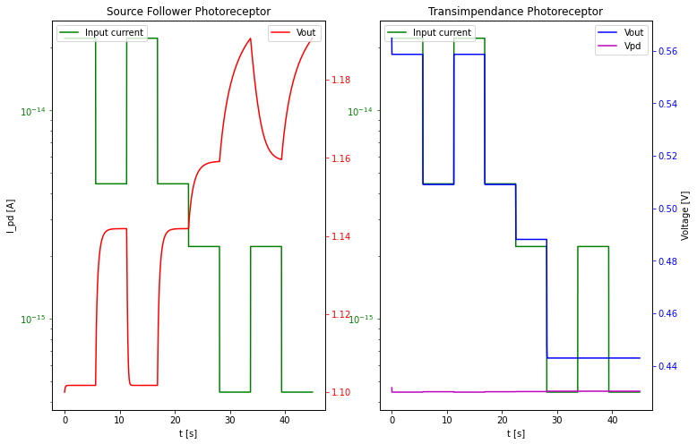

```python
import matplotlib.pyplot as plt # plotting
import numpy as np # for math
from scipy.integrate import solve_ivp # for timestepping ODEs

V_sf0= [1.1]# initial condition of v, just guess it to be approx Vg-a bit, e.g. 1.4-.3
sf_sol=solve_ivp(sfdvdt, (time_basis[0],time_basis[-1]),V_sf0, t_eval=time_basis,
                 rtol=1e-9,atol=1e-19, method='LSODA',
                 #rtol=1e-9,atol=1e-20, method='Radau',
                 args=(1.4,C_pd))
# output is sol.t and sol.y
if sf_sol.message is not None:
    print(sf_sol.message)
v_sf=sf_sol.y[0]
t_sf=sf_sol.t


# TODO you can solve the TI by filling in below
# check DC output
ib=I_b
ip=I_pd(0)
V_ti0=ti_dc(I_b,ip)
print(f'DC output of TI with I_b={eng(I_b)} and I_pd={eng(ip)} are vpd={eng(V_ti0[0])} vout={eng(V_ti0[1])}')
#
C_out=1e-15
ti_sol=solve_ivp(tidvdt, (time_basis[0],time_basis[-1]),V_ti0, t_eval=time_basis, rtol=1e-10, atol=1e-21, method='LSODA',args=(I_b,I_pd,V_e,C_pd,C_out))

#rtol=1e-9, atol=1e-19, method='RK45', rtol=1e-10, atol=1e-21, method='Radau'
### output is sol.t and sol.y
if ti_sol.message is not None:
    print(ti_sol.message)
v_ti=ti_sol.y[1]
t_ti=ti_sol.t
v_pd=ti_sol.y[0]
t_pd=ti_sol.t

# use this plotting style to put several plots sharing same x-axis
# we will plot V_sf together with the input photocurrent
# using another axis since it is volts, not current, and linear not log
fig=plt.figure(figsize=(12,8))
ax1 = plt.subplot(121)
ax2 = plt.subplot(122, sharex = ax1)

ax1.plot(time_basis,photocurrent_waveform,'g')
ax1.set_yscale('log')
ax1.set_xscale('linear')
ax1.tick_params(axis='y', colors='green')
ax1.set_xlabel('t [s]')
ax1.set_ylabel('I_pd [A]')
ax1.title.set_text('Source Follower Photoreceptor')
ax2.title.set_text('Transimpendance Photoreceptor')

ax3=ax1.twinx()
ax3.plot(t_sf,v_sf,'r-')
ax3.tick_params(axis='y', colors='red')
ax1.legend(['Input current'], loc='upper left')
ax3.legend(['Vout'], loc='upper right')

ax2.set_yscale('log')
ax2.set_xlabel('t [s]')

ax2.tick_params(axis='y', colors='green')
ax2.set_xscale('linear')


ax2.plot(time_basis,photocurrent_waveform,'g',)
ax2.legend(['Input current'], loc='upper left')

# TODO: Uncomment for TI photoreceptor
ax4=ax2.twinx()
ax4.set_ylabel('Voltage [V]')
#ax4.set_ylim([0.4,0.8])
ax4.plot(t_ti, v_ti,'b-',t_pd,v_pd,'m-')
ax4.tick_params(axis='y', colors='blue')
ax4.legend(['Vout', 'Vpd'], loc='upper right')
```

Note that in above transient solution, you might get a startup glitch particularly for the TI photoreceptor because your TI DC solution at the starting time is not quite correct. It means that the V_pd and V_out and not consistent, and so the circuit will go through a short period of adjustment to come to the steady-state level.

### Exercise 3: Small signal modeling

You already did the most difficult part which is the large signal modeling. Now we will fix the operating point around some DC level and compute the small signal transfer functions. From these we can see the cutoff frequencies and stability.

### Exercise 3.1: AC transfer functions (Bode plots) of static vs. active photorecptors

**(a)** Write the small-signal differential equations for the simple photoreceptor and the unity-gain feedback photoreceptor assuming photodiode capacitance $C_{pd}$ and (for the feedback photoreceptor) output load capacitance $C_{out}$. For the feedback photoreceptor, you can assume that that amplifier has a output resistance $g_{out}$=$I_b$/$V_e$ (recall that the DC voltage gain is A=-$g_m$/$g_{out}$).

**(b)** From the differential equations, derive the transfer functions $H(s)$ for each circuit.

Your equations should end up with time constants $\tau_{in}$ (for the photodiode node) and $\tau_{out}$ for the feedback photoreceptor.

For this derivation, the input to the circuit is the small-signal photocurrent $i_{pd}$ which is its deviation from the DC value $I_{pd}$. The output is the small signal output voltage $v_{out}$. But since the circuit is a log photoreceptor, a better way to express the transfer function is to write it as output voltage per log input current. Thus $H(s)$ will be the transimpedance 'gain' that transduces from $i_{pd}/I_{pd}$ to $v_{out}$, i.e. the units of H(s) are volts/(fractional change in current).

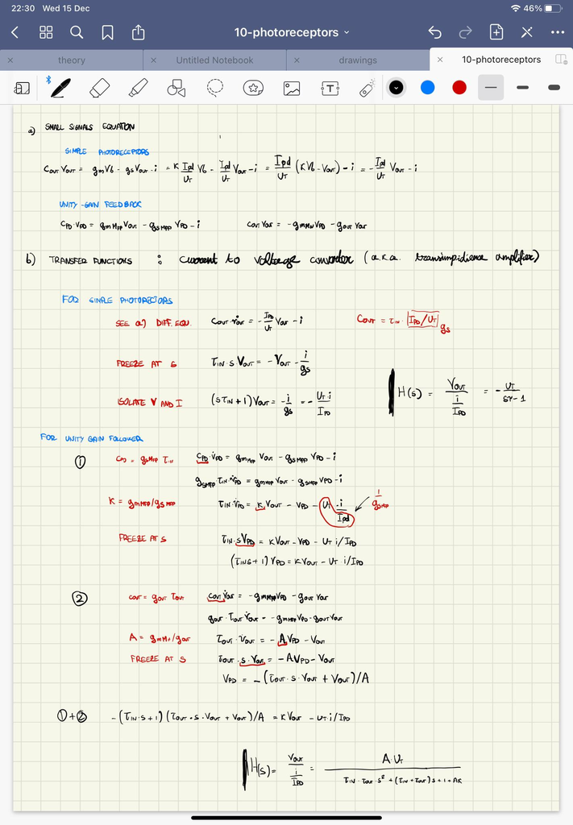

**(c)** The TI feedback should make the TI photoreceptor faster to respond to changes in photocurrent than the SF photoreceptor (and also noisier).

By setting $\tau_{out}$ to zero (taking the limit as $\tau_{out}$ goes to zero), compute the expected speedup from the feedback. I.e., what is the ratio of cutoff frequency of TI to SF circuit when $I_b$ is really large? You will see if it true (at least in the model) in the Bode magnitude transfer function plots.

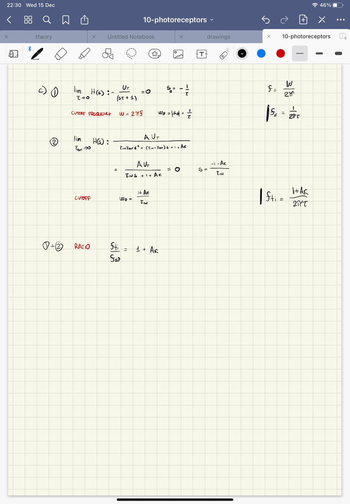

**(d)** Plot the magnitude of the transfer functions versus frequency, assuming reasonable values for $\tau_{in}$, $\tau_{out}$, etc and an intermediate DC value of photocurrent, e.g. $I_{pd}$=1pA. You can assume that the bias current of the amplifier for the feedback photoreceptor is $I_b$=10nA and $V_e$=10V.

Remember that frequency in radians per second is $w$=$2 \pi f$ where $f$ is frequency in Hertz.

You can use numpy to compute the magnitude of the complex transfer function by using $s$=$jw$ where $j$ is $\sqrt{-1}$.

Assume the DC photocurrent is still photocurrent_amps from above.

```
source follower photodiode capacitance C_pd=100fF and tau_sf=550.12ms
SF cutoff frequency: 289.31mHz
transimpedance TI cutoff frequency: 74.35Hz
```

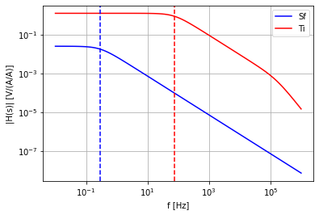

```python
import matplotlib.pyplot as plt # plotting
import numpy as np # for math

Ipd_dim=photocurrent_total_amps

freq = np.logspace(-2,6,100) # plot from 1kHz to 1GHz
w=2*np.pi*freq
tau_sf = C_pd*U_T/Ipd_dim # tau_sf = C_pd/gs_sf
H_sf = U_T/(np.sqrt(np.square(w*tau_sf)+1))
sf_cutoff_hz=1/(2*np.pi*tau_sf)

print(f'source follower photodiode capacitance C_pd={eng(C_pd)}F and tau_sf={eng(tau_sf)}s\n'
      f'SF cutoff frequency: {eng(sf_cutoff_hz)}Hz')

# TODO TI photoreceptor

tau_in=C_pd*U_T/Ipd_dim
tau_out=C_out*V_e/I_b
A= kappa*V_e/U_T
H_ti=A/(np.sqrt(np.square(w*(tau_in+tau_out))+np.square(kappa*A-w*w*tau_in*tau_out)))

ti_cutoff_hz=sf_cutoff_hz*(kappa*A+1)

print(f'transimpedance TI cutoff frequency: {eng(ti_cutoff_hz)}Hz')


fig,ax1=plt.subplots(sharex=True)
ax1.plot(freq,H_sf,'b',freq,H_ti,'r')
ax1.axvline(sf_cutoff_hz, color='b', linestyle = '--', label="source-follower f")
ax1.axvline(ti_cutoff_hz, color='r', linestyle = '--', label="transimpedance f")
#ax1.set_ylim([0,None])
ax1.set_yscale('log')
ax1.set_xscale('log')
#ax1.tick_params(axis='y', colors='green')
ax1.set_xlabel('f [Hz]')
ax1.set_ylabel('|H(s)| [V/(A/A)]')
ax1.grid()
ax1.legend(["Sf","Ti"])
```

**(c)** Comment on your results. Can you see the effect of feedback on the bandwidth in the TI circuit? Can you observe some ringing? I.e. is the circuit overdamped or underdamped at this $I_b$ and $I_{pd}$?

### Exercise 4: Root-locus plot of TI photoreceptor

As the photocurrent increases, it should be clear that the single pole of the SF photoreceptor moves farther away from the origin, as it speeds up.

Here you will compute the poles of the TI photoreceptor transfer function and then plot their locations on the complex plane as a function of the amplfier bias current $I_b$, given a fixed photocurrent $I_{pd}$.

The two poles of the quadratic demoninator $D(s)$ of $H(s)$ will either both be real or form a complex conjugate pair (since all the coefficients of the polynominal are real).

**(a)** First let's define a function to get the poles and the Q factor given the circuit parameters. Remember that a second order system (with no zeros) can be described by a transfer function of the type $H(s)=\frac{A}{\frac{1}{\omega_0^2}s^2+\frac{1}{Q\omega_0}s+1}$, where $\omega_0$ (natural frequency) and $Q$ (quality factor) are characteristics of the system.

```python
def get_poles(Ipd,Ib,C_pd,C_out,V_e=V_e,U_T=U_T,kappa=kappa):
    # TODO:
    tau_in=C_pd*U_T/Ipd
    tau_out=C_out*V_e/Ib
    coef2=tau_in*tau_out
    coef1=tau_in+tau_out
    coef0=1+kappa*V_e/U_T
    Q=np.sqrt(tau_in*tau_out)/(tau_in+tau_out)*np.sqrt(kappa*V_e/U_T+1)

    # apply quadratic formula to find roots of the transfer function denominator
    # 0j in sqrt forces result to be complex
    pole1=(-coef1+np.sqrt(0j+coef1*coef1-4*coef0*coef2))/(2*coef2)
    pole2=(-coef1-np.sqrt(0j+coef1*coef1-4*coef0*coef2))/(2*coef2)
    return [pole1,pole2,Q]
```

**(b)** Now let's plot the root locus. The resulting plot is a trajectory in the complex plane as a function of $I_b$

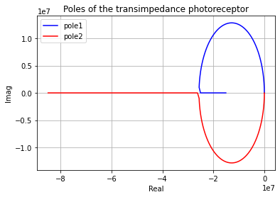

```python
import matplotlib.pyplot as plt # plotting
import numpy as np # for math

Ib_sweep = np.logspace(-15,-6,10000) # define range of Ib, adjust it to show the loop
Ipd_bright = 100e-12 # Photocurrent of 100pA

pole1,pole2,Q=get_poles(Ipd=Ipd_bright,Ib=Ib_sweep,C_pd=C_pd,C_out=C_out,V_e=V_e)

# plot
fig,ax1=plt.subplots(sharex=True)
ax1.plot(np.real(pole1),np.imag(pole1),'b')
ax1.plot(np.real(pole2),np.imag(pole2),'r')
ax1.set_xlabel('Real')
ax1.set_ylabel('Imag')
ax1.legend(['pole1','pole2'])
ax1.title.set_text('Poles of the transimpedance photoreceptor')
ax1.grid()
plt.show()
```

As you should be able to see in the root locus plot, for some values of $I_b$ both poles lie in the real axis, but by decreasing $I_b$, the poles become complex cojugates.

Let's now see the impact of pole location on the transient behavior of the circuit.

**(c)** First, for a particular photocurrent (which of course is not true in practice, it varies tremendously), find the minimum value of $I_b$ that results in a critically damped circuit. In the exactly critically-damped condition, Q equals 0.5, and the transient response should show no ringing since it consists of 2 low pass filters in series with equal time constants. This bias current is also the minimum value of $I_b$ that results in real valued poles at that photocurrent.

For the photocurrent, you can use the DC photocurrent under the illumination condition at the start of the waveform, which is called Ipd_bright.

```
Q: 0.4996108949416342
Ib_Qhalf: 5.136e-07A
```

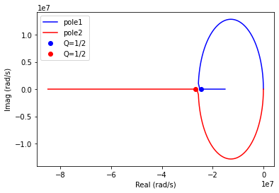

```python
# plot root locus again
fig,ax1=plt.subplots(sharex=True)
ax1.plot(np.real(pole1),np.imag(pole1),'b')
ax1.plot(np.real(pole2),np.imag(pole2),'r')
ax1.set_xlabel('Real (rad/s)')
ax1.set_ylabel('Imag (rad/s)')
ax1.legend(['pole1','pole2'])

#TODO fill expression Ib that results in a Q of 0.5
Ib_Qhalf=C_out*V_e*4*(kappa*V_e/U_T+1)*Ipd_bright/(C_pd*U_T)
pole1_Qhalf,pole2_Qhalf,Q_Qhalf=get_poles(Ipd=Ipd_bright,Ib=Ib_Qhalf,C_pd=C_pd,C_out=C_out,V_e=V_e)
ax1.plot(np.real(pole1_Qhalf),np.imag(pole1_Qhalf),'bo')
ax1.plot(np.real(pole2_Qhalf),np.imag(pole2_Qhalf),'ro')
ax1.legend(['pole1','pole2','Q=1/2','Q=1/2'])

print(f"Q: {Q_Qhalf}")
print(f"Ib_Qhalf: {Ib_Qhalf}A")
```

Note that you might have made some small approximations that result in the $Q=1/2$ poles not quite coming together on the real axis.

I.e. in the transfer function $H(s)$, maybe you dropped a constant term?

Or maybe to find the $Q=1/2$ condition, you simplified by assuming $\tau_2<<\tau_1$?

**(d)** Let's now look at the transient response of a TI photoreceptor operating under such conditions. First let's define a small signal transient input photocurrent

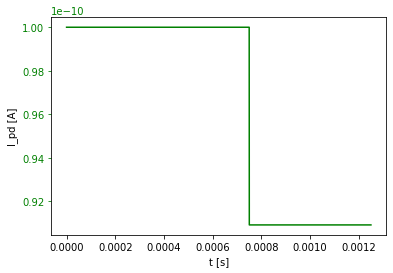

```python
sigdc_ss=Ipd_bright
#sigdc=1e-15
signal_contrast_ss=1.1 # contrast in each half, i.e. cont=10 means that the bright part will be 10 times the dark half period, 2 means 2 times
tau_ss=C_pd*U_T/sigdc_ss
t_warmup=tau_ss*30
t_total=t_warmup+tau_ss*20
Ipd_warmup=Ipd_bright
Ipd_final=Ipd_bright/signal_contrast_ss

def Ipd_step_func(t,I_t0=Ipd_warmup, I_t1=Ipd_final, t_warmup=t_warmup):
    if t<t_warmup:
        return I_t0
    else:
        return I_t1

dt_ss=tau_ss/1000
time_basis_ss=np.arange(0,t_total,dt_ss) # start,stop,step generate time basis that is nper long
npts_ss=len(time_basis_ss)

# compute actual Ipd for timesteps
Ipd_ss=np.empty(npts_ss)
for t,i in zip(time_basis_ss,range(npts_ss)):
    Ipd_ss[i]=Ipd_step_func(t)
fig,ax1=plt.subplots(sharex=True)
ax1.plot(time_basis_ss,Ipd_ss,'g',)
#ax1.set_ylim([0,None])
ax1.set_yscale('linear')
ax1.set_xscale('linear')
ax1.tick_params(axis='y', colors='green')
ax1.set_xlabel('t [s]')
ax1.set_ylabel('I_pd [A]')
```

**(e)** Observe the transient response of the photoreceptor under such conditions. Does it behave as expected? Try also other values of Q, both above and below 0.5. Plot them in the root locus and observe the transient response. When is the system overdamped and when is it underdamped? Observe how the root locus trajectory changes with $I_b$.

```python
# initial condition
V_ti0=ti_dc(Ib_Qhalf,Ipd_bright,I_0=I_0,V_e=V_e,U_T=U_T,kappa=kappa)
print(f'DC output of TI with Ib={eng(Ib_Qhalf)} and Ip={eng(Ipd_bright)} are vpd={eng(V_ti0[0])} vout={eng(V_ti0[1])}')
ti_sol=solve_ivp(tidvdt, (time_basis_ss[0],time_basis_ss[-1]),
                 V_ti0, t_eval=time_basis_ss, rtol=1e-9, atol=1e-19, method='Radau',
                 args=(Ib_Qhalf,Ipd_step_func,V_e,C_pd,C_out))
# output is sol.t and sol.y
if ti_sol.message is not None:
    print(ti_sol.message)
v_ti_Qhalf=ti_sol.y[1]
t_ti_Qhalf=ti_sol.t
v_pd_Qhalf=ti_sol.y[0]
t_pd_Qhalf=ti_sol.t

ib_factor=2 # how much larger and smaller to try seeing how sensitive is the Q=1/2 condition

# now solve for a bit larger Ib
ib=Ib_Qhalf*ib_factor
V_ti0=ti_dc(ib,Ipd_bright,I_0=I_0,V_e=V_e,U_T=U_T,kappa=kappa)
print(f'DC output of TI with Ib={eng(ib)} and Ip={eng(Ipd_bright)} are vpd={eng(V_ti0[0])} vout={eng(V_ti0[1])}')

ti_sol=solve_ivp(tidvdt, (time_basis_ss[0],time_basis_ss[-1]),
                 V_ti0, t_eval=time_basis_ss, rtol=1e-9, atol=1e-19, method='Radau',
                 args=(ib,Ipd_step_func,V_e,C_pd,C_out))
# output is sol.t and sol.y
if ti_sol.message is not None:
    print(ti_sol.message)
v_ti_Qhalf1=ti_sol.y[1]
t_ti_Qhalf1=ti_sol.t
v_pd_Qhalf1=ti_sol.y[0]
t_pd_Qhalf1=ti_sol.t

# and solve for a bit smaller Ib
ib=Ib_Qhalf/ib_factor
V_ti0=ti_dc(ib,Ipd_bright,I_0=I_0,V_e=V_e,U_T=U_T,kappa=kappa)
print(f'DC output of TI with Ib={eng(ib)} and Ip={eng(Ipd_bright)} are vpd={eng(V_ti0[0])} vout={eng(V_ti0[1])}')
ti_sol=solve_ivp(tidvdt, (time_basis_ss[0],time_basis_ss[-1]),
                 V_ti0, t_eval=time_basis_ss, rtol=1e-9, atol=1e-19, method='Radau',
                 args=(ib,Ipd_step_func,V_e,C_pd,C_out))
# output is sol.t and sol.y
if ti_sol.message is not None:
    print(ti_sol.message)
v_ti_Qhalf2=ti_sol.y[1]
t_ti_Qhalf2=ti_sol.t
v_pd_Qhalf2=ti_sol.y[0]
t_pd_Qhalf2=ti_sol.t
```

```
DC output of TI with Ib=513.60n and Ip=100p are vpd=554.82m vout=981.35m
The solver successfully reached the end of the integration interval.
DC output of TI with Ib=1.03u and Ip=100p are vpd=576.48m vout=1.01
The solver successfully reached the end of the integration interval.
DC output of TI with Ib=256.80n and Ip=100p are vpd=533.16m vout=954.28m
The solver successfully reached the end of the integration interval.
```

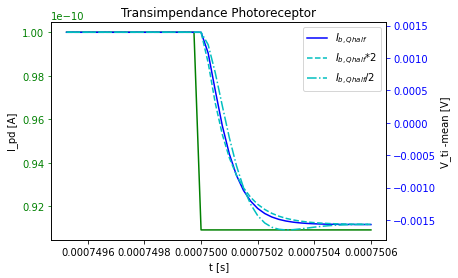

```python
# use this plotting style to put several plots sharing same x-axis
# we will plot V_sf together with the input photocurrent
# using another axis since it is volts, not current, and linear not log

t_start = t_warmup-tau_ss/50
t_end = t_warmup+tau_ss/40
six=np.argmax(time_basis_ss>t_start)
eix=np.argmax(time_basis_ss>t_end)
r=range(six,eix) # range to plot, to eliminate startup transient

# because of transient, we need to limit the output voltage plotting range
# around the DC level before and after the step
fig=plt.figure(figsize=(12,8))
fig,ax1=plt.subplots(sharex=True)
# tlim=[t_start,t_end]
# lookup idx of time point just before step
# vlim=[v_ti_Qhalf2[len(time_basis_ss)//5],v_ti_Qhalf2[-1]*1.1]

ax1.plot(time_basis_ss[r],Ipd_ss[r],'g')
ax1.set_yscale('linear')
ax1.set_xscale('linear')
ax1.tick_params(axis='y', colors='green')
ax1.set_xlabel('t [s]')
ax1.set_ylabel('I_pd [A]')
# ax1.set_xlim(tlim)

ax2=ax1.twinx()
ax2.plot(t_ti_Qhalf[r],v_ti_Qhalf[r]-np.mean(v_ti_Qhalf[r]),'b-')
ax2.plot(t_ti_Qhalf1[r],v_ti_Qhalf1[r]-np.mean(v_ti_Qhalf1[r]),'c--')
ax2.plot(t_ti_Qhalf2[r],v_ti_Qhalf2[r]-np.mean(v_ti_Qhalf2[r]),'c-.')
# ax2.set_xlim(tlim)
ax2.set_ylabel('V_ti -mean [V]')
# ax2.set_ylim(vlim)
ax2.tick_params(axis='y', colors='blue')
ax2.legend(['$I_{b,Qhalf}$','$I_{b,Qhalf}$'+f'*{ib_factor}','$I_{b,Qhalf}$'+f'/{ib_factor}'], loc='upper right')
ax2.title.set_text('Transimpendance Photoreceptor')
plt.show()
```

Let's simulate open loop amplifier with very slow ramp of input voltage to meausre the open loop voltage gain and compare it with theory

```
Amplifier gain: Measured -334.39, predicted from kappa*Ve/U_T=320
```

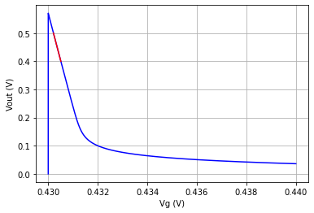

```python
tt=1
v0=.43
v1=.44
def ampdvdt(t,vd):
    vg=v0-(v0-v1)*t/tt
    id=id_sub(vg,0,vd,V_e=V_e,kappa=kappa)
    i=I_b-id
    vdot= i / 1e-15
    # print(f'vg={vg}V vd={vd}V id={id}A idiff={i}A')
    return vdot

t=np.linspace(0,tt,10000)
vd0=[0]
s=solve_ivp(ampdvdt,(t[0],t[-1]),
            vd0, t_eval=t, rtol=1e-9, atol=1e-12, method='Radau')
vd=s.y[0]
vg=v0-(v0-v1)*t/tt
plt.plot(vg,vd,'-b')
r=[i for i in range(len(vd)) if vd[i]> .4 and vd[i]<.5]
plt.xlabel('Vg (V)')
plt.ylabel('Vout (V)')
plt.plot(vg[r],vd[r],'r-')
plt.grid(True)
A_meas=linregress(vg[r],vd[r])[0]
A_pred=kappa*V_e/U_T
print(f'Amplifier gain: Measured {eng(A_meas)}, predicted from kappa*Ve/U_T={eng(A_pred)}')
```

**(f)** If the poles are not purely real, the photoreceptor output will have a ringing behavior. The larger the Q, the more the system will ring. In the TI photoreceptor, Q is maximum when $\tau_{out}=\tau_{in}$. Find the value of $I_b$ which results in maximum Q, and plot it on the root locus. Compare the value obtained for Q with the theoretical value.

```
Q: 8.958236433584458
Ib: 3.9999999999999996e-10
```

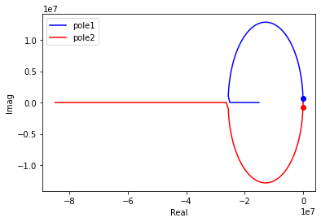

```python
# plot root locus
fig,ax1=plt.subplots(sharex=True)
ax1.plot(np.real(pole1),np.imag(pole1),'b')
ax1.plot(np.real(pole2),np.imag(pole2),'r')
ax1.set_xlabel('Real')
ax1.set_ylabel('Imag')
ax1.legend(['pole1','pole2'])

# TODO fill the expression with the value of Ib which maximizes Q
Ib_Qmax=Ipd_bright*V_e*C_out/(C_pd*U_T)
pole1_Qmax,pole2_Qmax,Q_Qmax=get_poles(Ipd=Ipd_bright,Ib=Ib_Qmax,C_pd=C_pd,C_out=C_out,V_e=V_e)
ax1.plot(np.real(pole1_Qmax),np.imag(pole1_Qmax),'bo')
ax1.plot(np.real(pole2_Qmax),np.imag(pole2_Qmax),'ro')

print(f"Q: {Q_Qmax}")
print(f"Ib: {Ib_Qmax}")
```

**(g)** Observe the transient response of the photoreceptor in such conditions. Does it behave as expected? Again, try other values of Q, both above and below the maximum. Plot them in the root locus and observe the transient response and how Q affects ringing.

```python
# initial condition
V_ti0=ti_dc(Ib_Qmax,Ipd_bright,I_0=I_0,V_e=V_e,U_T=U_T,kappa=kappa)
ti_sol=solve_ivp(tidvdt, (time_basis_ss[0],time_basis_ss[-1]),
                 V_ti0, t_eval=time_basis_ss, rtol=1e-9, atol=1e-19, method='Radau',
                 args=(Ib_Qmax,Ipd_step_func,V_e,C_pd,C_out))
t_start = t_warmup-tau_ss/30
t_end = t_warmup+tau_ss*2
six=np.argmax(time_basis_ss>t_start)
eix=np.argmax(time_basis_ss>t_end)
r=range(six,eix) # range to plot, to eliminate startup transient

# output is sol.t and sol.y
if ti_sol.message is not None:
    print(ti_sol.message)
v_ti_Qmax=ti_sol.y[1][r]
t_ti_Qmax=ti_sol.t[r]
v_pd_Qmax=ti_sol.y[0][r]
t_pd_Qmax=ti_sol.t[r]

ti_sol=solve_ivp(tidvdt, (time_basis_ss[0],time_basis_ss[-1]),
                 V_ti0, t_eval=time_basis_ss, rtol=1e-9, atol=1e-19, method='LSODA',
                 args=(Ib_Qmax*2,Ipd_step_func,V_e,C_pd,C_out))
# output is sol.t and sol.y
if ti_sol.message is not None:
    print(ti_sol.message)
v_ti_Qmax1=ti_sol.y[1][r]
t_ti_Qmax1=ti_sol.t[r]
v_pd_Qmax1=ti_sol.y[0][r]
t_pd_Qmax1=ti_sol.t[r]

ti_sol=solve_ivp(tidvdt, (time_basis_ss[0],time_basis_ss[-1]),
                 V_ti0, t_eval=time_basis_ss, rtol=1e-9, atol=1e-19, method='LSODA',
                 args=(Ib_Qmax/2,Ipd_step_func,V_e,C_pd,C_out))
# output is sol.t and sol.y
if ti_sol.message is not None:
    print(ti_sol.message)
v_ti_Qmax2=ti_sol.y[1][r]
t_ti_Qmax2=ti_sol.t[r]
v_pd_Qmax2=ti_sol.y[0][r]
t_pd_Qmax2=ti_sol.t[r]
```

```
The solver successfully reached the end of the integration interval.
The solver successfully reached the end of the integration interval.
The solver successfully reached the end of the integration interval.
```

[figure not shown]

```python
# use this plotting style to put several plots sharing same x-axis
# we will plot V_sf together with the input photocurrent
# using another axis since it is volts, not current, and linear not log
fig=plt.figure(figsize=(12,8))
fig,ax1=plt.subplots(sharex=True)


ax1.plot(time_basis_ss[r],Ipd_ss[r],'g')
ax1.set_yscale('linear')
ax1.set_xscale('linear')
ax1.tick_params(axis='y', colors='green')
ax1.set_xlabel('t [s]')
ax1.set_ylabel('I_pd [A]')

ax2=ax1.twinx()
#ax2.plot(t_ti_Qmax,v_ti_Qmax,'b-')
ax2.plot(t_ti_Qmax,v_ti_Qmax-v_ti_Qmax[0],'b-')
ax2.plot(t_ti_Qmax1,v_ti_Qmax1-v_ti_Qmax1[0],'c--')
ax2.plot(t_ti_Qmax2,v_ti_Qmax2-v_ti_Qmax2[0],'c-.')
#ax2.plot(t_pd,v_pd,'m-')
ax2.tick_params(axis='y', colors='blue')
ax2.legend(['$I_{b,Qmax}$','$I_{b,Qmax}$/2','$I_{b,Qmax}$*2'], loc='upper right')
ax2.title.set_text('Transimpendance Photoreceptor')
ax2.title.set_text('Transimpendance Photoreceptor')
ax2.grid()
```